# ECo 602 - Analysis of Environmental Data

Final Project Template: Data Analysis

Sarah Traore

Fall 2020

Everything above this line is the header.

# Introduction

The following code is a data analysis on data collected of two species of small mammals in the Atlantic Forest of Brazil.

# Data Anaylsis

```r
require(here)
dat_delomys = read.csv(here("data", "delomys.csv"))
```

# Data Exploration

The exploration will be mainly perform on the body mass and length columns of the data

## Numerical Exploration

```r
#Display summary statistics of the data (mean, median, quantiles, min & max)

summary(dat_delomys$body_mass)
```

```
##    Min. 1st Qu.  Median    Mean 3rd Qu.    Max.
##    5.00   35.00   43.00   44.06   54.00  105.00
```

```r
summary(dat_delomys$body_length)
```

```
##    Min. 1st Qu.  Median    Mean 3rd Qu.    Max.
##    49.0   106.0   116.0   114.7   124.0   265.0
```

```r
# Perform a test of normality (alpha = 0.05)

shapiro.test(dat_delomys$body_mass)
```

```
##
##  Shapiro-Wilk normality test
##
## data:  dat_delomys$body_mass
## W = 0.99506, p-value = 4.33e-05
```

```r
shapiro.test(dat_delomys$body_length)
```

```
##
##  Shapiro-Wilk normality test
##
## data:  dat_delomys$body_length
## W = 0.87609, p-value < 2.2e-16
```

## Graphical Exploration

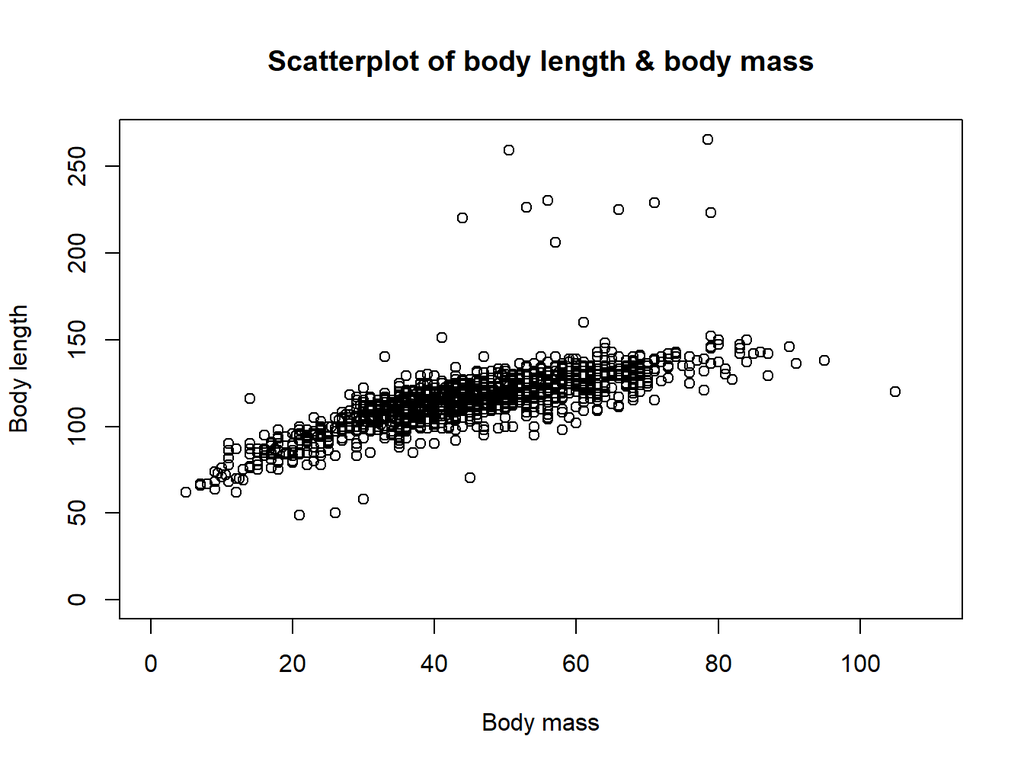

```r
# Create a scatterplot of body mass and body length

plot(body_length ~ body_mass, data = dat_delomys,
     main = "Scatterplot of body length & body mass", col='black',
     pch = 1, cex = 1, xlab = "Body mass", ylab = "Body length",
     xlim = c(0, 110), ylim =c(0,266))
```

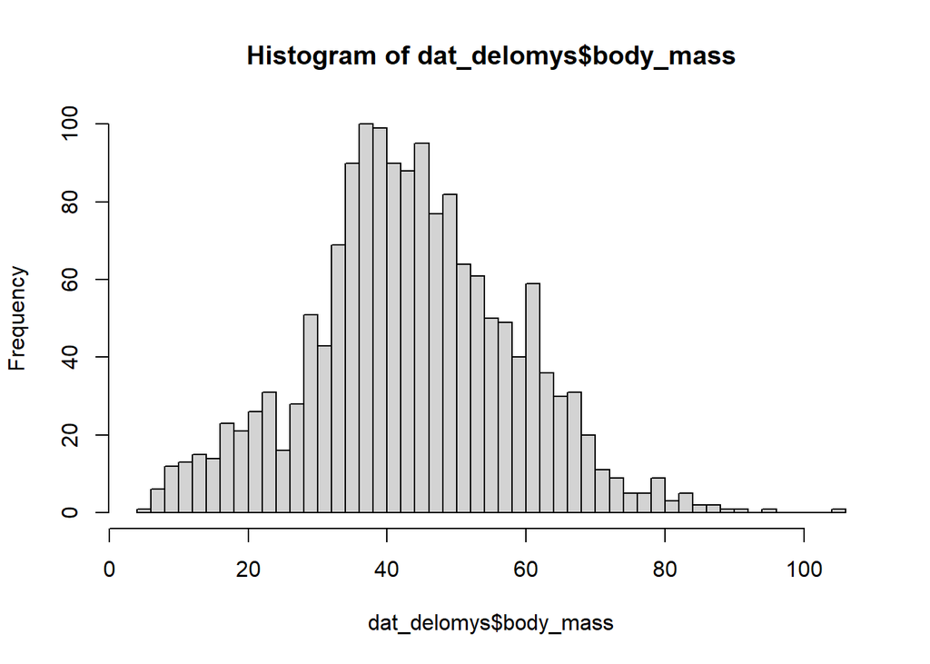

```r
#Histogram of body mass

hist(dat_delomys$body_mass, breaks = 40)
```

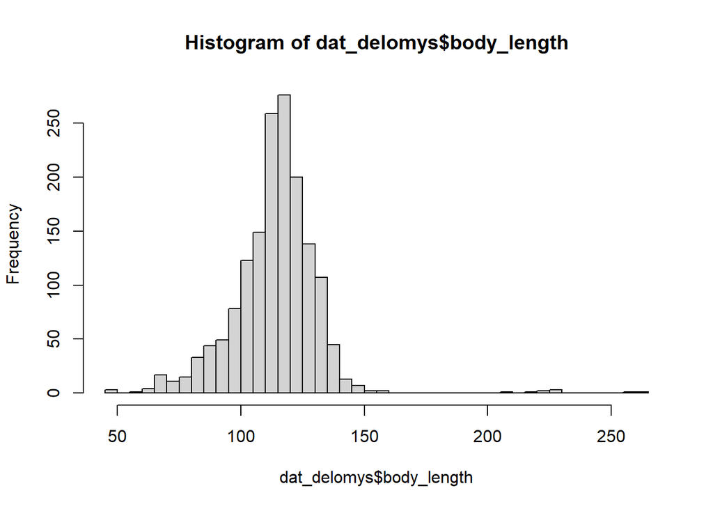

```r
#Histogram of body length

hist(dat_delomys$body_length, breaks = 40)
```

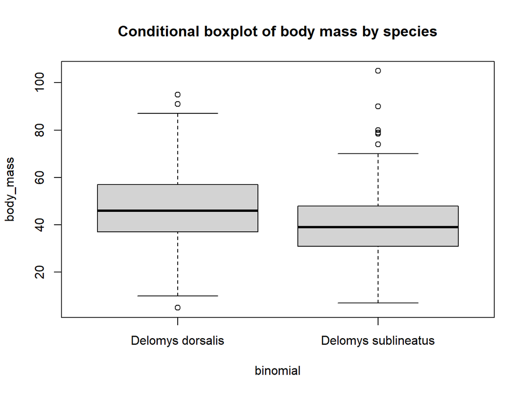

```r
#Conditonal boxplot of body mass, conditioned on species

boxplot(body_mass ~ binomial, data = dat_delomys,
        main = "Conditional boxplot of body mass by species")
```

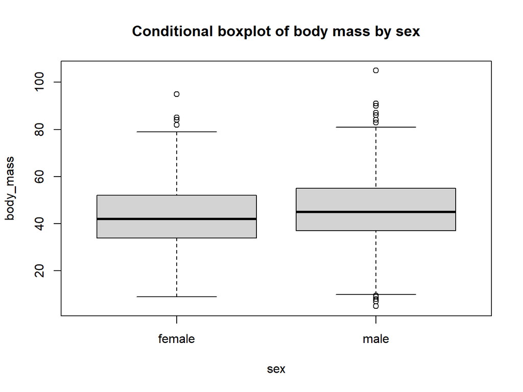

```r
#Conditonal boxplot of body mass, conditioned on sex

boxplot(body_mass ~ sex, data = dat_delomys,
        main = "Conditional boxplot of body mass by sex")
```

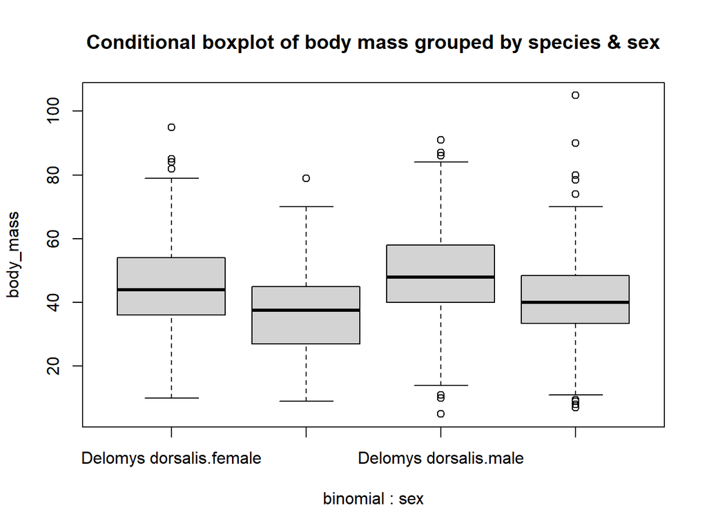

```r
#conditional boxplot of body mass, conditioned on both species and sex

boxplot(body_mass ~ binomial * sex, data = dat_delomys,
        main = "Conditional boxplot of body mass grouped by species & sex")
```

1- The scatterplot of body mass and length shows a linear relationship between body mass and length

3- The numerical normality tests on body mass and body length show values of p-value respectively of 4.33e-05 and 0 that are both lower than 0.05.

This clearly rejects the null hypothesis of the shapiro test and suggests that the data aren’t normally-distributed. So, the numerical normality tests are in accordance with the histograms shapes.

4- The body mass conditioned on sex is not spread and there is a very small difference between female and male body masses. On the contrary, there is a clear difference in body mass between the two species.

# Model Building

```r
#Model 1: Simple linear regression body_length ~ body_mass
fit_1 = lm(body_length ~ body_mass, data = dat_delomys)
summary(fit_1)
```

```
##
## Call:
## lm(formula = body_length ~ body_mass, data = dat_delomys)
##
## Residuals:
##     Min      1Q  Median      3Q     Max
## -48.888  -5.398   0.104   4.859 138.663
##
## Coefficients:
##             Estimate Std. Error t value Pr(>|t|)
## (Intercept) 76.12466    0.91581   83.12   <2e-16 ***
## body_mass    0.87550    0.01969   44.46   <2e-16 ***
## ---
## Signif. codes:  0 '***' 0.001 '**' 0.01 '*' 0.05 '.' 0.1 ' ' 1
##
## Residual standard error: 11.67 on 1583 degrees of freedom
## Multiple R-squared:  0.5553, Adjusted R-squared:  0.5551
## F-statistic:  1977 on 1 and 1583 DF,  p-value: < 2.2e-16
```

```r
# Model 2: 1-way ANOVA body_mass ~ sex
fit_2 = lm(body_mass ~ sex, data = dat_delomys)
summary(fit_2)
```

```
##
## Call:
## lm(formula = body_mass ~ sex, data = dat_delomys)
##
## Residuals:
##     Min      1Q  Median      3Q     Max
## -40.496  -8.711  -0.496   9.504  59.504
##
## Coefficients:
##             Estimate Std. Error t value Pr(>|t|)
## (Intercept)  42.7115     0.5289  80.756  < 2e-16 ***
## sexmale       2.7841     0.7456   3.734 0.000195 ***
## ---
## Signif. codes:  0 '***' 0.001 '**' 0.01 '*' 0.05 '.' 0.1 ' ' 1
##
## Residual standard error: 14.82 on 1578 degrees of freedom
##   (5 observations deleted due to missingness)
## Multiple R-squared:  0.008758,   Adjusted R-squared:  0.00813
## F-statistic: 13.94 on 1 and 1578 DF,  p-value: 0.0001951
```

```r
# Model 3: 1-way ANOVA body_mass ~ binomial
fit_3 = lm(body_mass ~ binomial, data = dat_delomys)
summary(fit_3)
```

```
##
## Call:
## lm(formula = body_mass ~ binomial, data = dat_delomys)
##
## Residuals:
##     Min      1Q  Median      3Q     Max
## -41.752  -9.069  -0.069   9.248  65.931
##
## Coefficients:
##                             Estimate Std. Error t value Pr(>|t|)
## (Intercept)                  46.7524     0.4500   103.9   <2e-16 ***
## binomialDelomys sublineatus  -7.6831     0.7605   -10.1   <2e-16 ***
## ---
## Signif. codes:  0 '***' 0.001 '**' 0.01 '*' 0.05 '.' 0.1 ' ' 1
##
## Residual standard error: 14.44 on 1583 degrees of freedom
## Multiple R-squared:  0.06058,    Adjusted R-squared:  0.05998
## F-statistic: 102.1 on 1 and 1583 DF,  p-value: < 2.2e-16
```

```r
#Model 4: 2-way additional ANOVA body_mass ~ sex + binomial
fit_4 = lm(body_mass ~ sex + binomial, data = dat_delomys)
summary(fit_4)
```

```
##
## Call:
## lm(formula = body_mass ~ sex + binomial, data = dat_delomys)
##
## Residuals:
##     Min      1Q  Median      3Q     Max
## -43.866  -8.866  -0.672   8.930  64.328
##
## Coefficients:
##                             Estimate Std. Error t value Pr(>|t|)
## (Intercept)                  45.0704     0.5556  81.114  < 2e-16 ***
## sexmale                       3.7954     0.7260   5.228 1.94e-07 ***
## binomialDelomys sublineatus  -8.1935     0.7610 -10.767  < 2e-16 ***
## ---
## Signif. codes:  0 '***' 0.001 '**' 0.01 '*' 0.05 '.' 0.1 ' ' 1
##
## Residual standard error: 14.31 on 1577 degrees of freedom
##   (5 observations deleted due to missingness)
## Multiple R-squared:  0.07663,    Adjusted R-squared:  0.07546
## F-statistic: 65.44 on 2 and 1577 DF,  p-value: < 2.2e-16
```

```r
# Model 5: 2-way ANOVA factorial body_mass ~ sex *binomial
fit_5 = lm(body_mass ~ sex * binomial, data = dat_delomys)
summary(fit_5)
```

```
##
## Call:
## lm(formula = body_mass ~ sex * binomial, data = dat_delomys)
##
## Residuals:
##     Min      1Q  Median      3Q     Max
## -43.884  -8.884  -0.647   8.945  64.353
##
## Coefficients:
##                                     Estimate Std. Error t value Pr(>|t|)
## (Intercept)                         45.05546    0.60530  74.435  < 2e-16 ***
## sexmale                              3.82809    0.89667   4.269 2.08e-05 ***
## binomialDelomys sublineatus         -8.14174    1.12810  -7.217 8.22e-13 ***
## sexmale:binomialDelomys sublineatus -0.09502    1.52859  -0.062     0.95
## ---
## Signif. codes:  0 '***' 0.001 '**' 0.01 '*' 0.05 '.' 0.1 ' ' 1
##
## Residual standard error: 14.31 on 1576 degrees of freedom
##   (5 observations deleted due to missingness)
## Multiple R-squared:  0.07664,    Adjusted R-squared:  0.07488
## F-statistic:  43.6 on 3 and 1576 DF,  p-value: < 2.2e-16
```

# Model Diagnostics

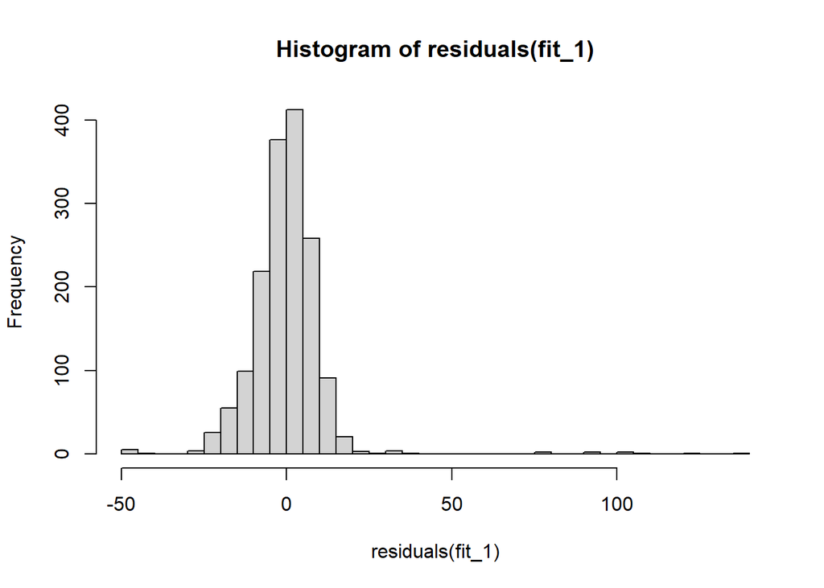

```r
#Histogram of model 1 residuals
hist(residuals(fit_1), breaks = 40)
```

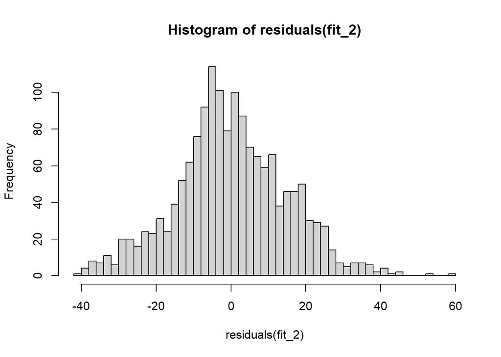

```r
#Histogram of model 2 residuals
hist(residuals(fit_2), breaks = 40)
```

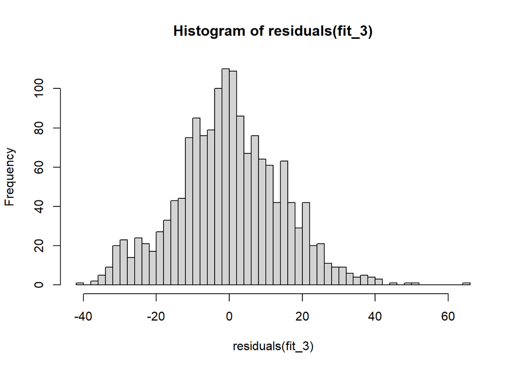

```r
#Histogram of model 3 residuals
hist(residuals(fit_3), breaks = 40)
```

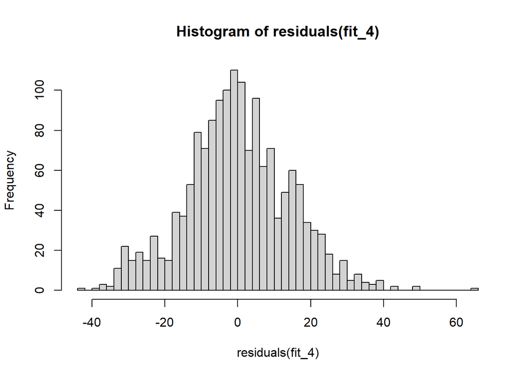

```r
#Histogram of model 4 residuals
hist(residuals(fit_4), breaks = 40)
```

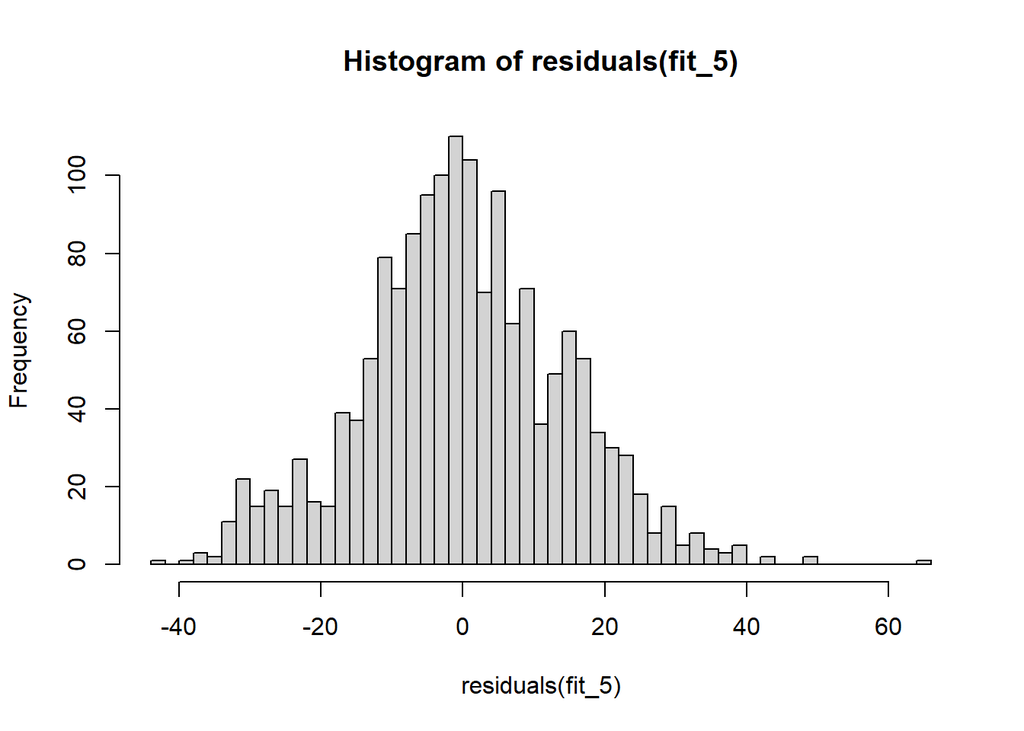

```r
#Histogram of model 5 residuals
hist(residuals(fit_5), breaks = 40)
```

The null hypothesis of the Shapiro test is:" the residuals are drawn from a normally-distributed population".

Let’s test the null hypothesis for each model.

```r
#Model 1
shapiro.test(residuals(fit_1))
```

```
##
##  Shapiro-Wilk normality test
##
## data:  residuals(fit_1)
## W = 0.73462, p-value < 2.2e-16
```

```r
#Model 2
shapiro.test(residuals(fit_2))
```

```
##
##  Shapiro-Wilk normality test
##
## data:  residuals(fit_2)
## W = 0.99563, p-value = 0.0001541
```

```r
#Model 3
shapiro.test(residuals(fit_3))
```

```
##
##  Shapiro-Wilk normality test
##
## data:  residuals(fit_3)
## W = 0.99535, p-value = 8.103e-05
```

```r
#Model 4
shapiro.test(residuals(fit_4))
```

```
##
##  Shapiro-Wilk normality test
##
## data:  residuals(fit_4)
## W = 0.99525, p-value = 6.805e-05
```

```r
#Model 5
shapiro.test(residuals(fit_5))
```

```
##
##  Shapiro-Wilk normality test
##
## data:  residuals(fit_5)
## W = 0.99526, p-value = 6.816e-05
```

# Model Interpretation

## Body Length

```r
knitr::kable(coef(summary(fit_1, digits = 3)))
```

|  | Estimate | Std. Error | t value | Pr(>\|t\|) |
| --- | --- | --- | --- | --- |
| (Intercept) | 76.1246565 | 0.9158120 | 83.12258 | 0 |
| body_mass | 0.8754988 | 0.0196905 | 44.46298 | 0 |

1- The mass/length relationship is a positive relationship. As the body mass increases, the body length increases too.

## Body Mass: Model Coefficients

```r
#Model 2
knitr::kable(coef(summary(fit_2)))
```

|  | Estimate | Std. Error | t value | Pr(>\|t\|) |
| --- | --- | --- | --- | --- |
| (Intercept) | 42.711465 | 0.5288929 | 80.756355 | 0.0000000 |
| sexmale | 2.784133 | 0.7456117 | 3.734024 | 0.0001951 |

```r
#Model 3
knitr::kable(coef(summary(fit_3)))
```

|  | Estimate | Std. Error | t value | Pr(>\|t\|) |
| --- | --- | --- | --- | --- |
| (Intercept) | 46.752427 | 0.4499933 | 103.89582 | 0 |
| binomialDelomys sublineatus | -7.683058 | 0.7604562 | -10.10322 | 0 |

```r
#Model 4
knitr::kable(coef(summary(fit_4)))
```

|  | Estimate | Std. Error | t value | Pr(>\|t\|) |
| --- | --- | --- | --- | --- |
| (Intercept) | 45.070355 | 0.5556429 | 81.113891 | 0e+00 |
| sexmale | 3.795395 | 0.7259609 | 5.228099 | 2e-07 |
| binomialDelomys sublineatus | -8.193492 | 0.7609985 | -10.766764 | 0e+00 |

```r
#Model 5
knitr::kable(coef(summary(fit_5)))
```

|  | Estimate | Std. Error | t value | Pr(>\|t\|) |
| --- | --- | --- | --- | --- |
| (Intercept) | 45.0554562 | 0.6052973 | 74.4352459 | 0.0000000 |
| sexmale | 3.8280908 | 0.8966667 | 4.2692460 | 0.0000208 |
| binomialDelomys sublineatus | -8.1417394 | 1.1281046 | -7.2171847 | 0.0000000 |
| sexmale:binomialDelomys sublineatus | -0.0950187 | 1.5285856 | -0.0621612 | 0.9504424 |

1- The base level for sex is female

2- The base level for binomial is Delomys dorsalis

4- The heavier species is Delomys dorsalis

## Body Mass: ANOVA

```r
#Model 2
knitr::kable(anova(fit_2))
```

|  | Df | Sum Sq | Mean Sq | F value | Pr(>F) |
| --- | --- | --- | --- | --- | --- |
| sex | 1 | 3061.678 | 3061.6779 | 13.94294 | 0.0001951 |
| Residuals | 1578 | 346507.131 | 219.5863 | NA | NA |

```r
#Model 3
knitr::kable(anova(fit_3))
```

|  | Df | Sum Sq | Mean Sq | F value | Pr(>F) |
| --- | --- | --- | --- | --- | --- |
| binomial | 1 | 21289.68 | 21289.6805 | 102.0751 | 0 |
| Residuals | 1583 | 330164.45 | 208.5688 | NA | NA |

```r
#Model 4
knitr::kable(anova(fit_4))
```

|  | Df | Sum Sq | Mean Sq | F value | Pr(>F) |
| --- | --- | --- | --- | --- | --- |
| sex | 1 | 3061.678 | 3061.6779 | 14.95838 | 0.0001144 |
| binomial | 1 | 23727.134 | 23727.1342 | 115.92320 | 0.0000000 |
| Residuals | 1577 | 322779.997 | 204.6798 | NA | NA |

```r
#Model 5
knitr::kable(anova(fit_5))
```

|  | Df | Sum Sq | Mean Sq | F value | Pr(>F) |
| --- | --- | --- | --- | --- | --- |
| sex | 1 | 3.061678e+03 | 3.061678e+03 | 14.948932 | 0.0001150 |
| binomial | 1 | 2.372713e+04 | 2.372713e+04 | 115.849977 | 0.0000000 |
| sex:binomial | 1 | 7.913846e-01 | 7.913846e-01 | 0.003864 | 0.9504424 |
| Residuals | 1576 | 3.227792e+05 | 2.048091e+02 | NA | NA |

1- The p-values for sex (model 2) and species (model 3) are both lower than the significant level alpha (0.05), so they are significant predictors for body mass since we can reject the null hypothesis.

2- There p-value for the factorial 2-way ANOVA (model 5) is 0.95 > 0.05, so there isn’t a significant interaction between species and sex.

3- The significance of either of the main effects (sex and species) does not differ much between the single-predictor models, the additive model, and the interactive model.

# Model Comparison: Body Mass

We use the AIC criterion to compare the models.

```r
AIC_2 = AIC(fit_2)
print(AIC_2)
```

```
## [1] 13006.8
```

```r
AIC_3 = AIC(fit_3)
print(AIC_3)
```

```
## [1] 12966.36
```

```r
AIC_4 = AIC(fit_4)
print(AIC_4)
```

```
## [1] 12896.73
```

```r
AIC_5 = AIC(fit_5)
print(AIC_5)
```

```
## [1] 12898.72
```

The 2-way additive ANOVA (model 4) and the 2-way factorial ANOVA (model 5) have the lowest AIC. However, I would choose the 2-way additive ANOVA because not only it has the lowest AIC, but also the interaction p-value of the other model is larger than α which does not show a significant interaction between the species and the sex.